# Project: Accidental Mortality Data Analysis

- Introduction
- Data Wrangling
- Exploratory Data Analysis
- Conclusions

## Introduction

> In this project, the correlations between various accidental mortality rates will be investigated for different countries in years 2002 and 2004. The accidental mortality rate variables include falls, burns, poisoning, and drownings mortality (age-adjusted and expressed per 100,000 people). The datasets were provided from Gapminder under the indicator names 'Burns deaths (per 100,000 people)', 'Drownings (per 100,000 people)', 'Falls, Deaths (per 100,000 people)', and 'Poisonings, deaths (per 100,000 people)'.

> The questions we will be aiming to answer are the following:
> - What is the most common cause of accidental mortality in the world of the variables analyzed?
> - Has accidental mortality rates in the world improved from 2002 to 2004?
> - Which countries have the lowest and highest accidental death rates?
> - How are the accidental mortality rate variables correlated to one another?

```python
# Import packaages and show plots in the notebook.
import pandas as pd
import matplotlib.pyplot as plt
import seaborn as sns
%matplotlib inline
```

## Data Wrangling

> In this section, we will do some preliminary analysis and manipulating of the datasets to convert the data into a form that can be easily analyzed. Since the data we want to analyze is in multiple csv files, we will also need to combine the datasets.

### General Properties

> To get an idea of what questions to ask and what data analysis needs to be done, we will look at the general properties of the data to see what is provided.

```python
# First, we will investigate the first few rows of the burn deaths data.
df_burn = pd.read_csv('Burns age-adjusted mortality.csv')
df_burn.head()
```

|  | Fires, age-adjusted mortality per 100 000 | 2002 | 2004 |
| --- | --- | --- | --- |
| 0 | Afghanistan | 5.460642 | 5.120083 |
| 1 | Albania | 0.271549 | 0.485215 |
| 2 | Algeria | 4.535572 | 3.856376 |
| 3 | Andorra | 0.254841 | 0.238900 |
| 4 | Angola | 9.622183 | 8.819596 |

```python
# Next, we can look at the shape and datatypes of the burn deaths data.
df_burn.info()
```

```
<class 'pandas.core.frame.DataFrame'>
RangeIndex: 192 entries, 0 to 191
Data columns (total 3 columns):
Fires, age-adjusted mortality per 100 000    192 non-null object
2002                                         192 non-null float64
2004                                         192 non-null float64
dtypes: float64(2), object(1)
memory usage: 4.6+ KB
```

```python
# Similarly, if we open the other three datasets, we will find that they all follow the same format for the columns and
#   have the same number of rows. This was checked with Excel and using another notebook. To prevent repetition, the
#   analysis is only shown for the drowning deaths dataset.
df_drowning = pd.read_csv('Drownings age-adjusted mortality.csv')
df_drowning.head()
```

|  | Drownings, age-adjusted mortality per 100 000 | 2002 | 2004 |
| --- | --- | --- | --- |
| 0 | Afghanistan | 8.894667 | 8.386345 |
| 1 | Albania | 1.223273 | 3.537699 |
| 2 | Algeria | 3.803705 | 2.521034 |
| 3 | Andorra | 0.705402 | 0.672039 |
| 4 | Angola | 19.186740 | 14.243567 |

```python
# We can see that the column names are the same for all the datasets, so we will need to rename the columns to
#   differentiate them when we combine the datasets. Now, looking at the shape and dataypes of the drowning data.
df_drowning.info()
```

```
<class 'pandas.core.frame.DataFrame'>
RangeIndex: 192 entries, 0 to 191
Data columns (total 3 columns):
Drownings, age-adjusted mortality per 100 000    192 non-null object
2002                                             192 non-null float64
2004                                             192 non-null float64
dtypes: float64(2), object(1)
memory usage: 4.6+ KB
```

```python
# The other datasets are read into a dataframe
df_fall = pd.read_csv('Falls age-adjusted mortality.csv')
df_poisoning = pd.read_csv('Poisonings age-adjusted mortality.csv')
```

Observing the general properties of the dataset, we can see that we have accidental mortality data for countries for the years 2002 and 2004. From this data, we can come up with the questions listed in the introduction which will be answered in the next sections of this project.

### Combining into a Single Dataset

> The data is contained in four different datasets, so we will need to merge the data into a single set and maybe perform some cleaning if required.

```python
# For all the datasets, we will change the column names into something more descriptive so we don't confuse the columns.
df_burn.columns = ['country', 'burn_2002', 'burn_2004']
df_drowning.columns = ['country', 'drowning_2002', 'drowning_2004']
df_fall.columns = ['country', 'fall_2002', 'fall_2004']
df_poisoning.columns = ['country', 'poisoning_2002', 'poisoning_2004']
```

```python
# Since all datasets have the same number of rows, it is likely that they include the same countries in the same order.
#   We will test this using a boolean statement. This will be done by using the all() function [1], which return True
#   if all values in a list are True
all(df_burn.country == df_drowning.country) & all(df_burn.country == df_fall.country) & all(df_burn.country == df_poisoning.country)
```

```
True
```

```python
# Now that it is confirmed that the 'country' column is equal and have the same indexes, we can add all the columns
#   into a single dataset.
df_combined = df_burn
df_combined['drowning_2002'] = df_drowning['drowning_2002']
df_combined['drowning_2004'] = df_drowning['drowning_2004']
df_combined['fall_2002'] = df_fall['fall_2002']
df_combined['fall_2004'] = df_fall['fall_2004']
df_combined['poisoning_2002'] = df_poisoning['poisoning_2002']
df_combined['poisoning_2004'] = df_poisoning['poisoning_2004']

# We look at the first few rows of the dataframe to make sure everything looks fine.
df_combined.head()
```

|  | country | burn_2002 | burn_2004 | drowning_2002 | drowning_2004 | fall_2002 | fall_2004 | poisoning_2002 | poisoning_2004 |
| --- | --- | --- | --- | --- | --- | --- | --- | --- | --- |
| 0 | Afghanistan | 5.460642 | 5.120083 | 8.894667 | 8.386345 | 6.331071 | 5.331774 | 5.220776 | 4.712897 |
| 1 | Albania | 0.271549 | 0.485215 | 1.223273 | 3.537699 | 0.788038 | 2.135770 | 1.288356 | 5.043472 |
| 2 | Algeria | 4.535572 | 3.856376 | 3.803705 | 2.521034 | 4.422987 | 3.915557 | 4.214998 | 3.600247 |
| 3 | Andorra | 0.254841 | 0.238900 | 0.705402 | 0.672039 | 2.160558 | 2.126071 | 2.593317 | 2.463189 |
| 4 | Angola | 9.622183 | 8.819596 | 19.186740 | 14.243567 | 7.728636 | 7.208484 | 12.891180 | 12.671692 |

### Replacing Null and Zero Values

> In this section, we will look at the combined dataset to see if there are any questionable values and replace them if necessary.

```python
# Next is to investigate the shape and datatypes of the combined dataset and see if anymore data cleaning, such as
#   filling in null values, is required.
df_combined.info()
```

```
<class 'pandas.core.frame.DataFrame'>
RangeIndex: 192 entries, 0 to 191
Data columns (total 9 columns):
country           192 non-null object
burn_2002         192 non-null float64
burn_2004         192 non-null float64
drowning_2002     192 non-null float64
drowning_2004     192 non-null float64
fall_2002         192 non-null float64
fall_2004         192 non-null float64
poisoning_2002    192 non-null float64
poisoning_2004    192 non-null float64
dtypes: float64(8), object(1)
memory usage: 13.6+ KB
```

```python
# The data seems clean with the desired datatypes and no null values. However, we also want to fill in zero values with
# with the mean because we assume that zero values are null points. This is required because when we plot the countries
# with the least accidental mortality rate, we do not want these to show up. We will use the replace function [3] for this.
df_combined['burn_2002'].replace(0, df_combined['burn_2002'].mean(), inplace=True)
df_combined['burn_2004'].replace(0, df_combined['burn_2004'].mean(), inplace=True)
df_combined['drowning_2002'].replace(0, df_combined['drowning_2002'].mean(), inplace=True)
df_combined['drowning_2004'].replace(0, df_combined['drowning_2004'].mean(), inplace=True)
df_combined['fall_2002'].replace(0, df_combined['fall_2002'].mean(), inplace=True)
df_combined['fall_2004'].replace(0, df_combined['fall_2004'].mean(), inplace=True)
df_combined['poisoning_2002'].replace(0, df_combined['poisoning_2002'].mean(), inplace=True)
df_combined['poisoning_2004'].replace(0, df_combined['poisoning_2004'].mean(), inplace=True)
df_combined.info()
```

```
<class 'pandas.core.frame.DataFrame'>
RangeIndex: 192 entries, 0 to 191
Data columns (total 9 columns):
country           192 non-null object
burn_2002         192 non-null float64
burn_2004         192 non-null float64
drowning_2002     192 non-null float64
drowning_2004     192 non-null float64
fall_2002         192 non-null float64
fall_2004         192 non-null float64
poisoning_2002    192 non-null float64
poisoning_2004    192 non-null float64
dtypes: float64(8), object(1)
memory usage: 13.6+ KB
```

## Exploratory Data Analysis

> Now that we have cleaned the data, we will try to systematically answer the questions we are aiming to answer with data visualizations.

### What is the most common cause of accidental mortality in the world of the variables analyzed? Has accidental mortality rates in the world improved from 2002 to 2004?

> To investigate these questions, we will look at the mean and some summary statistics of the data for each accidental mortality cause in both 2002 and 2004. We will then plot this in a double bar chart so we can visualize which accidental mortality causes have the highest global mean for both years.

```python
# First, we will look at some summary statistics of the combined dataset
df_combined.describe()
```

|  | burn_2002 | burn_2004 | drowning_2002 | drowning_2004 | fall_2002 | fall_2004 | poisoning_2002 | poisoning_2004 |
| --- | --- | --- | --- | --- | --- | --- | --- | --- |
| count | 192.000000 | 192.000000 | 192.000000 | 192.000000 | 192.000000 | 192.000000 | 192.000000 | 192.000000 |
| mean | 3.568370 | 3.417545 | 5.629718 | 5.314813 | 4.925724 | 4.659248 | 4.605944 | 4.323206 |
| std | 3.246311 | 3.025339 | 4.396919 | 4.571390 | 3.603426 | 3.222415 | 6.786786 | 5.625096 |
| min | 0.151243 | 0.063291 | 0.133447 | 0.347905 | 0.030216 | 0.019409 | 0.091285 | 0.049654 |
| 25% | 0.794257 | 0.789006 | 2.297455 | 2.185494 | 2.705158 | 2.580282 | 0.835074 | 0.866394 |
| 50% | 2.886510 | 3.046000 | 4.926330 | 4.341315 | 4.410905 | 4.342663 | 2.777760 | 2.835439 |
| 75% | 5.387554 | 5.234851 | 7.549523 | 6.968325 | 6.238660 | 6.077678 | 5.725577 | 5.152720 |
| max | 15.889740 | 14.327616 | 20.274990 | 26.637497 | 23.388960 | 17.845737 | 59.829980 | 41.142811 |

From the summary statistics, we see the means of the data along with other information about the variability of the data. Now that we have an idea what the data will look like, we can visualize this data by plotting as a double bar chart for 2002 and 2004. From the bar chart, we can then easily observe which accidental mortality rate is has the highest mean and how they compare between the two years.

```python
# To make it easier to plot, we will divide the dataset into the 2002 data and 2004 data using iloc
df_2002 = df_combined.iloc[:,[0,1,3,5,7]]
df_2004 = df_combined.iloc[:,[0,2,4,6,8]]
```

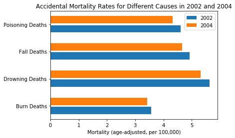

```python
# We will plot a double bar chart [2] of the mortality rates of each of the variables for 2002 and 2004. We will also
#   create a labels variable to hold the label names.
labels = ['Burn Deaths', 'Drowning Deaths', 'Fall Deaths', 'Poisoning Deaths']
plt.barh([1,4,7,10], df_2002.iloc[:,[1,2,3,4]].mean(), label='2002')
plt.barh([2,5,8,11], df_2004.iloc[:,[1,2,3,4]].mean(), label='2004')
plt.title('Accidental Mortality Rates for Different Causes in 2002 and 2004');
plt.xlabel('Mortality (age-adjusted, per 100,000)');
plt.yticks([1.5,4.5,7.5,10.5], labels);
plt.legend();
```

Now that the data has been plotted as a double bar chart, we can conveniently observe the trends in the data and make tentative conclusions about the data.

### Which countries have the highest and lowest accidental mortality rates?

> Next, we will investigate which countries have the highest and lowest accidental mortality rates. We have 192 countries in our dataset, so there is too much data to visualize if we plot all the countries in one chart. Instead, we will look at the top 10 countries with the highest and lowest accidental death rates in 2004. We choose 2004 as the only data to analyze because it is more modern, and therefore probably a better indicator of the current situation.

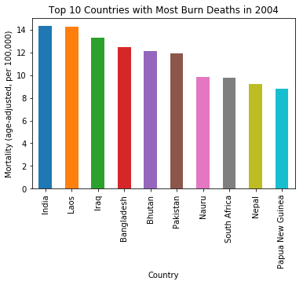

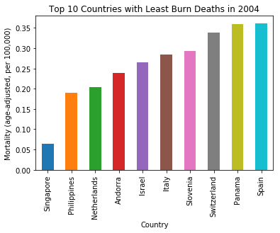

```python
#   We will plot the 10 countries with the highest and lowest accidental death rates in 2004. This will be done using the
#   nlargest [4] and nsmallest [5] functions. This will be done for all the accidental mortality rate variables.
df_combined.nlargest(10, 'burn_2004').plot('country', 'burn_2004',kind='bar', title='Top 10 Countries with Most Burn Deaths in 2004', legend=False);
plt.xlabel('Country');
plt.ylabel('Mortality (age-adjusted, per 100,000)');
df_combined.nsmallest(10, 'burn_2004').plot('country', 'burn_2004',kind='bar', title='Top 10 Countries with Least Burn Deaths in 2004', legend=False);
plt.xlabel('Country');
plt.ylabel('Mortality (age-adjusted, per 100,000)');
```

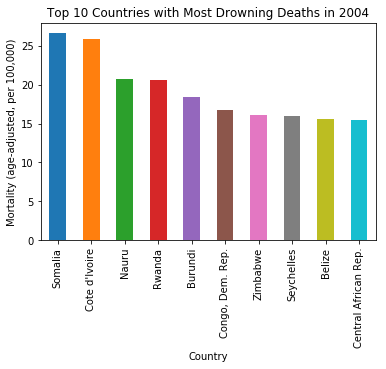

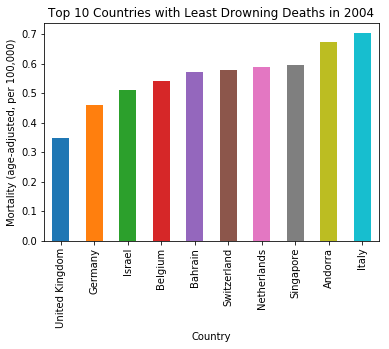

```python
# The top 10 countries for most and least drowning deaths
df_combined.nlargest(10, 'drowning_2004').plot('country', 'drowning_2004',kind='bar', title='Top 10 Countries with Most Drowning Deaths in 2004', legend=False);
plt.xlabel('Country');
plt.ylabel('Mortality (age-adjusted, per 100,000)');
df_combined.nsmallest(10, 'drowning_2004').plot('country', 'drowning_2004',kind='bar', title='Top 10 Countries with Least Drowning Deaths in 2004', legend=False);
plt.xlabel('Country');
plt.ylabel('Mortality (age-adjusted, per 100,000)');
```

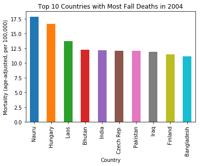

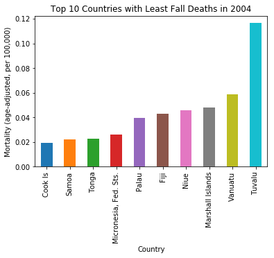

```python
# The top 10 countries for most and least fall deaths
df_combined.nlargest(10, 'fall_2004').plot('country', 'fall_2004',kind='bar', title='Top 10 Countries with Most Fall Deaths in 2004', legend=False);
plt.xlabel('Country');
plt.ylabel('Mortality (age-adjusted, per 100,000)');
df_combined.nsmallest(10, 'fall_2004').plot('country', 'fall_2004',kind='bar', title='Top 10 Countries with Least Fall Deaths in 2004', legend=False);
plt.xlabel('Country');
plt.ylabel('Mortality (age-adjusted, per 100,000)');
```

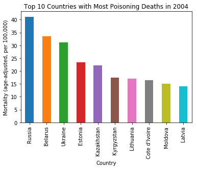

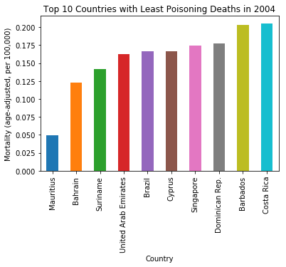

```python
# The top 10 countries for most and least poisoning deaths
df_combined.nlargest(10, 'poisoning_2004').plot('country', 'poisoning_2004',kind='bar', title='Top 10 Countries with Most Poisoning Deaths in 2004', legend=False);
plt.xlabel('Country');
plt.ylabel('Mortality (age-adjusted, per 100,000)');
df_combined.nsmallest(10, 'poisoning_2004').plot('country', 'poisoning_2004',kind='bar', title='Top 10 Countries with Least Poisoning Deaths in 2004', legend=False);
plt.xlabel('Country');
plt.ylabel('Mortality (age-adjusted, per 100,000)');
```

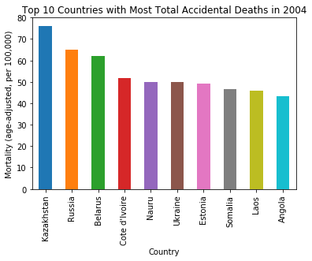

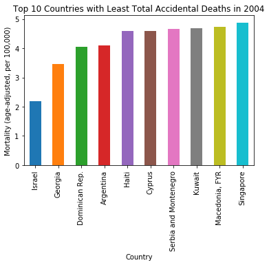

```python
# Finally, we will also sum up all the accidental mortality rates to see which countries have the highest total
#   accidental mortality rate. This will be done by creating new columns by summing up the values.
df_combined['total_2002'] = df_combined['burn_2002'] + df_combined['fall_2002'] + df_combined['drowning_2002'] + df_combined['poisoning_2002']
df_combined['total_2004'] = df_combined['burn_2004'] + df_combined['fall_2004'] + df_combined['drowning_2004'] + df_combined['poisoning_2002']
df_2002['total_2002'] = df_combined['total_2002']
df_2004['total_2004'] = df_combined['total_2004']

# We also plot these results for 2004
df_combined.nlargest(10, 'total_2004').plot('country', 'total_2004',kind='bar', title='Top 10 Countries with Most Total Accidental Deaths in 2004', legend=False);
plt.xlabel('Country');
plt.ylabel('Mortality (age-adjusted, per 100,000)');
df_combined.nsmallest(10, 'total_2004').plot('country', 'total_2004',kind='bar', title='Top 10 Countries with Least Total Accidental Deaths in 2004', legend=False);
plt.xlabel('Country');
plt.ylabel('Mortality (age-adjusted, per 100,000)');
```

The results will be discussed in the 'Conclusion' section of this project.

### How are the accidental mortality rate variables correlated to one another?

> Finally, we will look at thow the accidental mortality rate variables are correlated. There are many ways to investigate correlation. We choose to plot scatter matrices for both the 2002 and 2004 data as a preliminary analysis of the correlations between the variables, and leave further analysis for projects in the future.

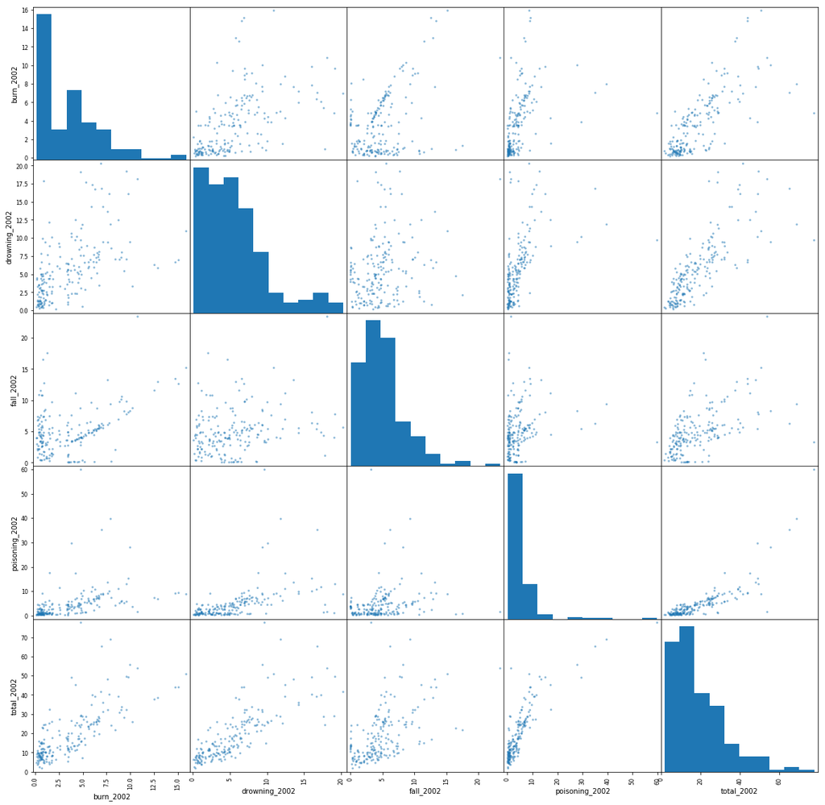

```python
# To get an idea of how the accident mortality rate variables are related to one another, we will use the pandas function
#   to plot a matrix of scatter plots for each variable on the 2002 data.
pd.plotting.scatter_matrix(df_2002, figsize=(20,20));
```

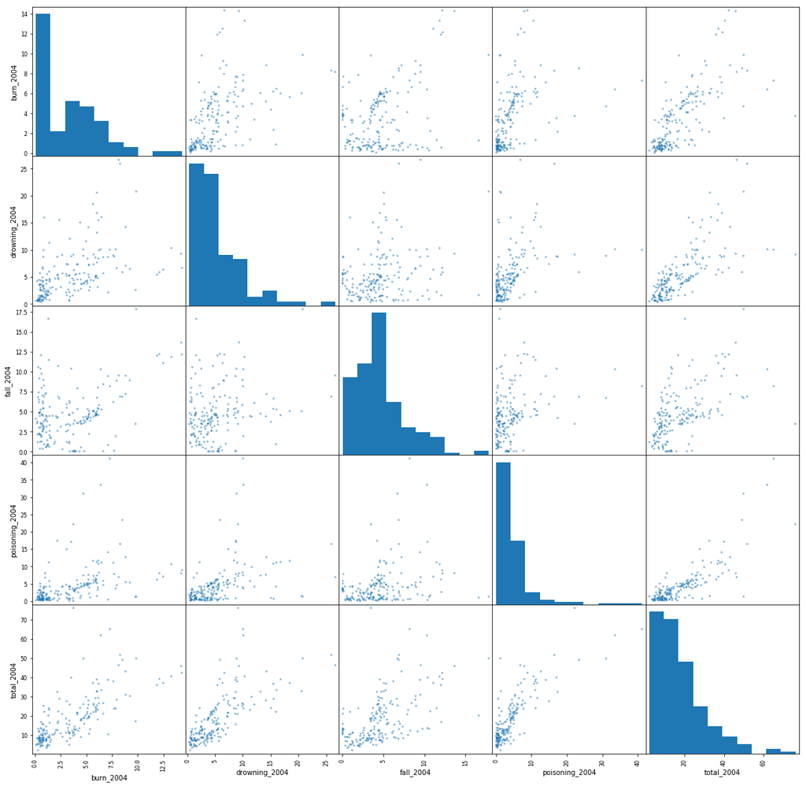

```python
# The same thing will be done with the 2004 data.
pd.plotting.scatter_matrix(df_2004, figsize=(20,20));
```

## Conclusions

> From the bar charts, we can see which countries have the highest and lowest mortality rates for each category in 2004. Singapore, Israel, and Italy have some of the least burn deaths and least drowning deaths. Additionally, Singapore is also on the least poisoning deaths chart. Countries with high accidental deaths from burns and falls include Laos, Iraq, and India. Additionally, we can see that the countries with the highest accidental mortality rates include Kazakhstan, Russia, and Belarus, while those with the least include Israel, Georgia, and Dominican Republic.

> Lastly, from the matrix of scatter plots, we see slight positive correlation for most of the accidental mortality rates in 2002 and 2004. This suggests that countries that a higher incidence of one kind of accidental death may also be more prone to another kind of accidental death. This may be because of a third variable that plays a role - a possible reason is that countries that invest less in accident prevention have higher accidental death mortalities. However, more investigation is needed to support this conclusion.

> There are some limitations to the analysis that should be pointed out. During the data cleaning process, zero values were replaced with the mean, which is inaccurate. It was assumed that zero values were an indicator of the absence of data instead of the value actually being zero, since it seems unlikely that a country has a zero accidental mortality rate. Also, we should consider the data quality and integrity - how accurately have the data been recorded and are there uniform recording procedures for every country? We can also look into how mortality rate is calculated, as the file mentions that it is age-adjusted. Finally, the trends found in this analysis can only suggest correlations, and we should be careful about implying causation merely based on the trends. Furthermore, additional statistical techniques such as regression can be applied, although it was decided that it is out of the scope of this project.

```python
# All done! Will save 3 csv files for the combined data, the 2002 data, and the 2004 data.
df_combined.to_csv('combined-accidental-death-analysis.csv')
df_2002.to_csv('2002-accidental-death-analysis.csv')
df_2004.to_csv('2004-accidental-death-analysis.csv')
```

## References

1. https://www.programiz.com/python-programming/methods/built-in/all
2. https://pythonspot.com/matplotlib-bar-chart/
3. https://pandas.pydata.org/pandas-docs/stable/generated/pandas.DataFrame.replace.html
4. https://pandas.pydata.org/pandas-docs/version/0.17.0/generated/pandas.DataFrame.nlargest.html
5. https://pandas.pydata.org/pandas-docs/stable/generated/pandas.DataFrame.nsmallest.html